# Team 1 ML project

The goal is to group the data points into k clusters. We want variability of observations within clusters is small while variability of observations between clusters is large.

– Initialization:

Randomly select k points in a feature space, these points will be our initial clusters.

– Iteration:

Step 1: Assign each observation to the cluster with the closest center in terms of Eucledian norm.

Step 2: Recalculate the center of each the k clusters.

Step 3. Repeat Step 1 and Step 2 until cluster assignment does not change.

```r
knitr::opts_chunk$set(message = FALSE, warning = FALSE)
library(rpart)
library(rpart.plot)
library(caret)
library(e1071)
```

Here we are reading the Parkinson data.

```r
dat <- read.csv("parkinsons.csv")
```

We used MDVP.Fo.Hz., MDVP.Fhi.Hz., MDVP.Flo.Hz. variables as the first step of our cluster analysis.

```r
cluster.vars <- dat[ , c("MDVP.Fo.Hz.", "MDVP.Fhi.Hz.", "MDVP.Flo.Hz.")]
dat$MDVP.Fo.Hz. <- scale(dat$MDVP.Fo.Hz.)
dat$MDVP.Fhi.Hz. <- scale(dat$MDVP.Fhi.Hz.)
dat$MDVP.Flo.Hz. <- scale(dat$MDVP.Flo.Hz.)
```

By experimenting we found 4 to be the optimal number of centers.

```r
km <- kmeans(cluster.vars, centers = 4, nstart = 50)
km
```

```
## K-means clustering with 4 clusters of sizes 102, 45, 37, 11
##
## Cluster means:
##   MDVP.Fo.Hz. MDVP.Fhi.Hz. MDVP.Flo.Hz.
## 1    124.2492     140.7668    102.56831
## 2    177.3965     224.8216     91.38016
## 3    209.3167     225.4312    192.24411
## 4    152.1458     510.8475     90.56327
##
## Clustering vector:
##   [1] 1 1 1 1 1 1 1 1 1 1 1 1 1 1 1 2 2 2 1 2 1 1 2 2 2 1 2 2 2 2 3 3 3 3 3 3 3
##  [38] 3 3 3 3 3 3 3 3 3 3 3 1 1 1 1 1 1 1 1 1 1 1 2 2 2 3 3 3 2 1 1 1 1 1 1 1 4
##  [75] 1 1 1 1 1 1 1 1 1 1 2 3 2 2 2 2 2 1 1 1 1 1 1 1 1 1 1 1 4 1 1 1 1 1 1 2 2
## [112] 3 3 3 2 4 4 4 4 2 4 2 2 2 2 2 2 2 1 1 1 1 1 1 1 1 1 1 1 1 2 2 3 2 3 2 3 3
## [149] 3 4 3 3 3 1 1 1 1 1 1 1 1 1 1 1 1 2 3 3 2 3 3 1 1 1 1 1 1 2 1 1 1 1 1 1 2
## [186] 1 4 4 1 2 2 2 2 4 2
##
## Within cluster sum of squares by cluster:
## [1] 118566.69  92539.74  71922.99  73889.88
##  (between_SS / total_SS =  84.6 %)
##
## Available components:
##
## [1] "cluster"      "centers"      "totss"        "withinss"     "tot.withinss"
## [6] "betweenss"    "size"         "iter"         "ifault"
```

We created a new feature called group1 by using the clusters above.

```r
dat$group1 <- factor(km$cluster)
```

Here we are deleting original three features used to create a “group1”.

```r
dat$MDVP.Fo.Hz. <- NULL
dat$MDVP.Fhi.Hz. <- NULL
dat$MDVP.Flo.Hz. <- NULL
```

We decided that one group is not enough so we formed another cluster using MDVP.Jitter…, MDVP.Jitter.Abs., MDVP.RAP, MDVP.PPQ and Jitter.DDP variables.

```r
cluster.vars2 <- dat[, c("MDVP.Jitter...", "MDVP.Jitter.Abs.", "MDVP.RAP", "MDVP.PPQ", "Jitter.DDP")]
```

By experimenting we found 4 to be the optimal number of centers.

```r
km1 <- kmeans(cluster.vars2, centers = 4, nstart = 50)
km1
```

```
## K-means clustering with 4 clusters of sizes 11, 57, 4, 123
##
## Cluster means:
##   MDVP.Jitter... MDVP.Jitter.Abs.    MDVP.RAP    MDVP.PPQ  Jitter.DDP
## 1    0.015903636     1.072727e-04 0.009188182 0.008829091 0.027561818
## 2    0.007815789     5.771930e-05 0.004177018 0.004352456 0.012530175
## 3    0.030370000     1.950000e-04 0.018415000 0.017017500 0.055255000
## 4    0.003829837     2.700813e-05 0.001885610 0.002103740 0.005658293
##
## Clustering vector:
##   [1] 2 2 2 2 1 2 4 4 4 4 4 4 4 4 4 4 4 2 2 2 2 4 4 4 2 2 4 4 4 4 4 4 4 4 4 4 4
##  [38] 4 4 4 4 4 4 4 4 4 4 4 4 4 4 4 4 4 2 2 2 2 2 2 4 4 4 4 4 4 2 2 2 2 2 2 4 4
##  [75] 4 4 4 4 2 2 2 2 2 4 2 4 4 4 4 2 2 4 4 4 4 4 4 1 1 1 3 1 3 4 4 4 4 4 4 2 2
## [112] 2 2 2 4 2 4 4 4 4 4 4 2 2 2 2 4 2 4 4 4 4 4 4 4 4 4 4 4 4 4 2 4 4 4 4 1 1
## [149] 1 1 1 3 3 2 2 2 2 1 2 2 4 2 2 4 2 4 4 4 2 4 4 4 4 4 4 4 4 4 4 4 4 4 4 4 4
## [186] 4 4 4 4 2 4 2 2 2 4
##
## Within cluster sum of squares by cluster:
## [1] 0.0003231425 0.0005738973 0.0001973128 0.0006410591
##  (between_SS / total_SS =  92.5 %)
##
## Available components:
##
## [1] "cluster"      "centers"      "totss"        "withinss"     "tot.withinss"
## [6] "betweenss"    "size"         "iter"         "ifault"
```

```r
dat$group2 <- factor(km1$cluster)
```

We are deleting original features used to create the variable “group2”.

```r
dat$MDVP.Jitter...<- NULL
dat$MDVP.Jitter.Abs. <- NULL
dat$MDVP.RAP <- NULL
dat$MDVP.PPQ <- NULL
dat$Jitter.DDP <- NULL
```

We repeated the same steps as above to create a shimmer group.

```r
cluster.vars3 <- dat[, c("MDVP.Shimmer", "MDVP.Shimmer.dB.", "Shimmer.APQ3", "Shimmer.APQ5", "MDVP.APQ", "Shimmer.DDA")]
```

```r
km3 <- kmeans(cluster.vars3, centers = 3, nstart = 50)
km3
```

```
## K-means clustering with 3 clusters of sizes 19, 127, 49
##
## Cluster means:
##   MDVP.Shimmer MDVP.Shimmer.dB. Shimmer.APQ3 Shimmer.APQ5   MDVP.APQ
## 1   0.07339474        0.7482105  0.038706316   0.04621579 0.06208737
## 2   0.01872299        0.1728661  0.009832913   0.01105472 0.01492283
## 3   0.04124408        0.3850816  0.021843061   0.02457571 0.03308224
##   Shimmer.DDA
## 1  0.11611737
## 2  0.02949898
## 3  0.06552980
##
## Clustering vector:
##   [1] 3 1 3 3 1 3 2 2 2 2 2 2 2 2 2 2 2 3 3 3 3 3 3 3 2 3 2 2 2 2 2 2 2 2 2 2 2
##  [38] 2 2 2 2 2 2 2 2 2 2 2 2 2 2 2 2 2 2 3 3 2 2 3 2 2 2 2 2 2 3 3 3 3 3 3 2 2
##  [75] 2 2 3 2 2 3 3 3 2 2 3 3 3 1 1 3 1 1 3 1 3 3 3 3 3 1 1 1 1 2 2 2 2 2 2 2 2
## [112] 2 2 2 2 2 2 2 2 2 2 2 3 2 2 2 2 2 2 2 2 2 2 2 3 3 3 3 3 2 3 1 3 2 2 2 1 1
## [149] 1 1 1 1 1 2 2 2 2 3 2 3 3 3 3 2 2 2 2 2 2 2 2 2 2 2 2 2 2 2 2 2 2 2 2 2 2
## [186] 2 2 2 2 2 3 2 2 2 2
##
## Within cluster sum of squares by cluster:
## [1] 0.6642844 0.3620063 0.2447553
##  (between_SS / total_SS =  83.5 %)
##
## Available components:
##
## [1] "cluster"      "centers"      "totss"        "withinss"     "tot.withinss"
## [6] "betweenss"    "size"         "iter"         "ifault"
```

```r
dat$shimmer <- factor(km3$cluster)
dat$MDVP.Shimmer <- NULL
dat$MDVP.Shimmer.dB. <- NULL
dat$Shimmer.APQ3 <- NULL
dat$MDVP.APQ <- NULL
dat$Shimmer.APQ5 <- NULL
dat$Shimmer.DDA <- NULL
```

Same analysis as above to create “nmeasure” variable.

```r
vars <- dat[, c("PPE", "spread1", "spread2")]
km4 <- kmeans(vars, centers = 3, nstart = 50)
km4
```

```
## K-means clustering with 3 clusters of sizes 90, 64, 41
##
## Cluster means:
##         PPE   spread1   spread2
## 1 0.2108834 -5.586970 0.2340019
## 2 0.1157045 -6.847058 0.1673148
## 3 0.3388531 -4.083376 0.3024683
##
## Clustering vector:
##   [1] 3 3 3 3 3 3 1 1 1 1 1 1 2 1 1 1 1 3 3 3 3 1 3 1 1 1 1 2 2 2 2 2 2 2 2 2 1
##  [38] 1 2 1 2 2 2 2 2 2 2 2 2 2 2 2 2 2 3 3 3 3 3 3 2 2 2 2 2 2 1 1 1 2 1 1 1 1
##  [75] 1 1 1 1 1 1 3 1 1 1 1 1 2 1 1 3 3 2 1 1 2 2 2 3 1 3 3 3 3 2 2 2 2 2 2 1 1
## [112] 2 1 1 2 3 1 3 1 1 1 3 1 1 1 1 1 1 2 1 1 1 1 2 1 1 3 3 1 1 3 1 1 1 1 1 3 3
## [149] 3 1 3 3 3 1 3 3 1 3 1 1 1 1 1 1 3 2 2 2 1 2 2 2 1 1 1 1 1 2 2 1 2 1 2 1 1
## [186] 1 2 2 2 2 2 1 2 2 1
##
## Within cluster sum of squares by cluster:
## [1] 12.61270 11.84305 14.87305
##  (between_SS / total_SS =  83.2 %)
##
## Available components:
##
## [1] "cluster"      "centers"      "totss"        "withinss"     "tot.withinss"
## [6] "betweenss"    "size"         "iter"         "ifault"
```

```r
dat$nmeasure <- factor(km4$cluster)
```

```r
dat$PPE <- NULL
dat$spread1 <- NULL
dat$spread2 <- NULL
```

In the following chunk we are dividing our dataset into a training and testing sets, such that the training set has 75% of the data while the testing set has the remaining 25%.

```r
set.seed(1)
partition <- createDataPartition(dat$status, p = 0.75, list = FALSE)
train <- dat[partition, ]
test <- dat[-partition, ]
mean(train$status)
```

```
## [1] 0.755102
```

```r
mean(test$status)
```

```
## [1] 0.75
```

We constructed a decision tree using all features.

```r
tree1 <- rpart(status ~ ., data = train, method = "class", control =   rpart.control(cp = 0.0001, maxdepth = 30))
tree1
```

```
## n= 147
##
## node), split, n, loss, yval, (yprob)
##       * denotes terminal node
##
##  1) root 147 36 1 (0.24489796 0.75510204)
##    2) nmeasure=2 53 25 0 (0.52830189 0.47169811)
##      4) DFA< 0.67186 16  1 0 (0.93750000 0.06250000) *
##      5) DFA>=0.67186 37 13 1 (0.35135135 0.64864865)
##       10) D2< 1.999221 7  1 0 (0.85714286 0.14285714) *
##       11) D2>=1.999221 30  7 1 (0.23333333 0.76666667) *
##    3) nmeasure=1,3 94  8 1 (0.08510638 0.91489362)
##      6) RPDE< 0.3990125 7  3 0 (0.57142857 0.42857143) *
##      7) RPDE>=0.3990125 87  4 1 (0.04597701 0.95402299) *
```

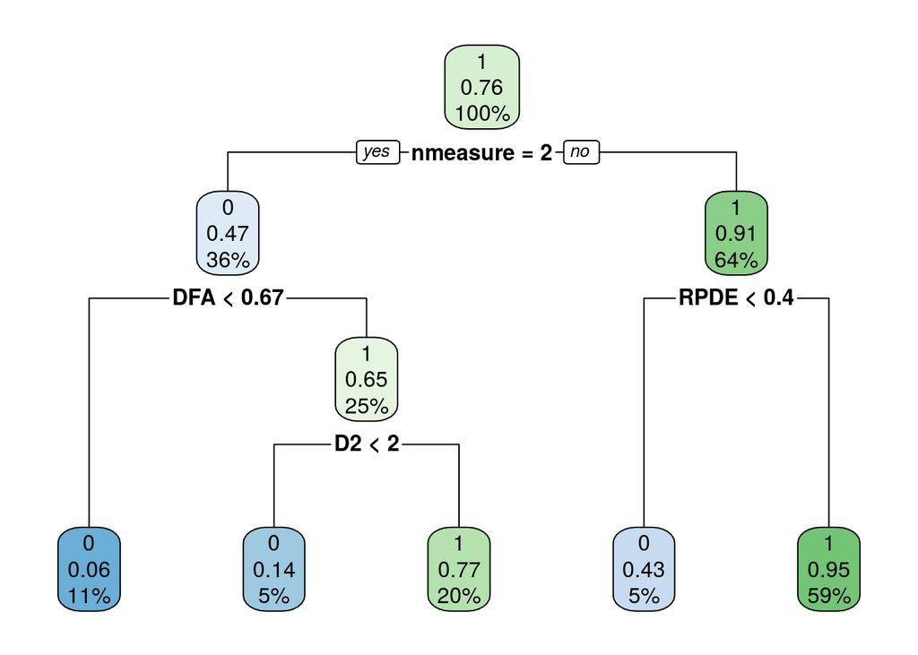

```r
rpart.plot(tree1)
```

We tested the model on the testing set, and constructed a confusion matrix. One can see that prediction accuracy of the model is 0.875 which is very good.

```r
pred <- predict(tree1, newdata = test)
pred.DT <- ifelse(pred[,2] > 0.9, "1", "0")
# saving predicted vector as factor
Pred <- as.factor(pred.DT)
# ordering the vectors
Predicted <- ordered(Pred, levels = c("1", "0"))
Actual <- ordered(test$status,levels = c("1", "0"))
# making confusion matrix
cm <-confusionMatrix(table(Predicted,Actual))
cm
```

```
## Confusion Matrix and Statistics
##
##          Actual
## Predicted  1  0
##         1 32  2
##         0  4 10
##
##                Accuracy : 0.875
##                  95% CI : (0.7475, 0.9527)
##     No Information Rate : 0.75
##     P-Value [Acc > NIR] : 0.02725
##
##                   Kappa : 0.6842
##
##  Mcnemar's Test P-Value : 0.68309
##
##             Sensitivity : 0.8889
##             Specificity : 0.8333
##          Pos Pred Value : 0.9412
##          Neg Pred Value : 0.7143
##              Prevalence : 0.7500
##          Detection Rate : 0.6667
##    Detection Prevalence : 0.7083
##       Balanced Accuracy : 0.8611
##
##        'Positive' Class : 1
##
```